title: “Predicting CSR Performance Score Using Linguistic Features in CEO Letter to shareholders in CSR Reporting: An Analysis of Statistical and Machine Learning Algorithms” author: “Abdlmutaleb Boshanna” data: “23/04/2020” output: pdf_document term: Winter 2020 - SMU —

### 1. A short description of CSR data that I will be using in my project, and the objective of the data analysis.

1. **Number of paragraphs: DESPC**
2. **Number of sentences: DESSC**
3. **Number of words: DESWC**
4. **Paragraph length, number of sentences, mean: DESPL**
5. **Paragraph length, number of sentences, standard deviation: DESPLd**
6. **Sentence length, number of words, mean: DESSL**
7. **Sentence length, number of words, standard deviation: DESSLd**
8. **Word length, number of syllables, mean: DESWLsy**
9. **Word length, number of syllables, standard deviation: DESWLsyd**
10. **Word length, number of letters, mean: DESWLlt**
11. **Word length, number of letters, standard deviation: DESWLltd**
12. **Narrativity: PCNARp**
13. **Syntactic Simplicity: PCSYNp**,
14. **Word Concreteness: PCCNCp**.
15. **Referential Cohesion: PCREFp**.
16. **Deep Cohesion: PCDCp**.
17. **Verb Cohesion: PCVERBp**.
18. **Connectivity: PCCONNp**.
19. **Temporality: PCTEMPp**.
20. **Flesch Reading Ease: RDFRE**.
21. **Flesch_Kincaid Grade Level: RDFKGL**
22. **Posemo: postiive tone, I use LIWC tool**
23. **Negemo: negative tone, I use LIWC tool**

**The a table of definition of each variable/feature can be found on the link below**: http://cohmetrix.com/

https://liwc.wpengine.com/

Bloomberg provides total CSR score performance. The goal of this project is to predict CSR performance using

1. **Regression problem**
2. **Classification problem**

**First**, a regression probelm, in this case, the outcome variable is continuing variable which is CSR performance (scaled from 0% to 100%).

1. **Parametric models** Simple OLS regression Ridge regression Lasso regression Ridge regression introducing polynomials and interactions Lasso regression introducing polynomials and interactions
2. **Non-Parametric models** single Decision tree regression Bagged regression Random forest regression Boosting regression

I will select the winner regression model based on Root Mean Squared Predicted Error (lowest RMSPE) and uncertainty (lowest variance)

**Second**, a classification problem: in this case, the outcome variable is label variable (0 or 1). I converted CSR performance (scaled from 0% to 100%) into a binary variable, 1 which indicates **excellent CSR performance**, and 0 indicates **not excellent” CSR performance**. percentiles are descriptions of quantiles relative to 100. Therefore, the 75th percentile (upper quartile) is 75% while the 25th percentile (lower quartile) is 25% or one quarter of the was up this rank order. A Company has excellent CSR performance if its CSR performance above 75%. However, a company does not have excellent CSR performance if its CSR performance below 75%.

1. **Non-Parametric models** Decision tree classifier Bagged classifier Random forest classifier Boosting classifier
2. **Parametric models** LPM classifier Ridge classifier Lasso classifier Ridge classifier introducing polynomials and interactions Lasso classifier introducing polynomials and interactions

**Third**, a classification problem: in this case, the outcome variable is label variable (0 or 1).I converted CSR performance (scaled from 0% to 100%) into a binary variable, 1 which indicates **poor CSR performance**, and 0 indicates **not poor” CSR performance**. A Company has poor CSR performance if its CSR performance below 25%. However, a company does not have poor CSR performance if its CSR performance above 25%.

1. **Non-Parametric models** Decision tree classifier Bagged classifier Random forest classifier Boosting classifier
2. **Parametric models** LPM classifier Ridge classifier Lasso classifier Ridge classifier introducing polynomials and interactions Lasso classifier introducing polynomials and interactions

**Finally**, a classification problem: in this case, using a different dataset, the outcome variable is label variable (0 or 1). CEOs write two letters to shareholders, one letter is included in a company annual report, the second one is included in CSR report. I extract the two letters from S&P 500 companies and based on the CEO letter lingustics features, I will predict whether CEO letter is from annual report Or CSR report. The idea is that I wanted to know if there is a differernce between CEOs wirting style in their letter to shareholder in annual report and thier wirting style in their letter to shareholder CSR report.

1. **Non-Parametric models** Decision tree classifier Bagged classifier Random forest classifier Boosting classifier
2. **Parametric models** LPM classifier Ridge classifier Lasso classifier Ridge classifier introducing polynomials and interactions Lasso classifier introducing polynomials and interactions

### 2. Import the data

```r
CSRdata <- read.csv("CSRScore.csv")
df <- CSRdata
str(df)
```

```
## 'data.frame':    805 obs. of  33 variables:
##  $ CSR                     : num  53.3 53.3 59.1 55 53.7 ...
##  $ DESPC                   : int  9 13 9 10 5 21 6 5 1 16 ...
##  $ DESSC                   : int  17 20 18 18 17 43 11 14 28 30 ...
##  $ DESWC                   : int  280 285 340 366 325 772 240 296 538 492 ...
##  $ DESPL                   : num  1.89 1.54 2 1.8 3.4 ...
##  $ DESPLd                  : num  1.97 1.2 1.32 1.23 1.95 ...
##  $ DESSL                   : num  16.6 14.4 18.9 20.5 19.3 ...
##  $ DESSLd                  : num  7.58 8.39 6.75 5.24 9.31 ...
##  $ DESWLsy                 : num  1.97 1.98 1.93 1.94 1.71 ...
##  $ DESWLsyd                : num  1.264 1.207 1.223 1.211 0.966 ...
##  $ DESWLlt                 : num  5.66 5.7 5.44 5.55 5.1 ...
##  $ DESWLltd                : num  3.42 3.35 3.22 3.26 2.85 ...
##  $ Year                    : int  2012 2013 2014 2015 2016 2010 2011 2012 2013 2014 ...
##  $ PCNARz                  : num  -0.803 -1.194 -1.394 -1.173 0.36 ...
```

[output cut: 19 more lines]

### 3. Data management: data cleaning and preparation.

Frist, I’d like to know how many missing values do we have in the data.

```r
sum(is.na(df))
```

```
## [1] 21
```

Second, I wanted to identify the number of NA’s in each column.

```r
colSums(is.na(df)|df == 'na')
```

```
##                      CSR                    DESPC                    DESSC
##                        0                        0                        0
##                    DESWC                    DESPL                   DESPLd
##                        0                        0                        0
##                    DESSL                   DESSLd                  DESWLsy
##                        0                        0                        0
##                 DESWLsyd                  DESWLlt                 DESWLltd
##                        0                        0                        0
##                     Year                   PCNARz                   PCSYNz
##                        0                        0                        0
##                   PCCNCz                   PCREFz                    PCDCz
##                        0                        0                        0
##                  PCVERBz                  PCCONNz                  PCTEMPz
##                        0                        0                        0
## Readabilityfleschkincaid           Readabilityfog                industry3
##                        0                        0                        0
##                 firmsize                    RDFRE                   RDFKGL
##                       17                        0                        0
##                   Posemo                   Negemo          Negativity_Freq
##                        2                        2                        0
##          positivity_Freq      ForwardLooking_Freq         Uncertainty_Freq
##                        0                        0                        0
```

```r
df <- df[complete.cases(df), ]
mean(df$CSR)
```

```
## [1] 42.07908
```

```r
sd(df$CSR)
```

```
## [1] 11.99
```

### 4. Regression problem

My outcome variable is **y** which is a **(CSR performance score)** and it is a continuous numberical variable. I am going to use first parametric models, and then non-parametric models to predict **y** based on **linguistic features in CEO letter to shareholders in CSR reporting** Afterwards, I will select the model with the best predictive power based on RMSPE and its uncertainty.

First, I’d like to calculate in-sample prediction with OLS and it’s R-squared. I did not split the data into train-set and test-set. I just use all the data.

```r
RMSPE <- c()
n <- 500
for(i in 1:n){

model <- lm(CSR ~., data = df)
yhat <- model$fitted.values
RMSPE <- sqrt(mean((df$CSR- yhat) ^ 2))
}
RMSPE
```

```
## [1] 10.3695
```

```r
mean(RMSPE)
```

```
## [1] 10.3695
```

```r
#summary(model) # I can find R-squared which is 25%. However, I will calculate R-squared.
```

Then, finding Predictive R-squared**:

```r
RSS <- sum((df$CSR- yhat) ^ 2)
TSS <- sum((df$CSR- mean(df$CSR)) ^ 2)
RSS
```

```
## [1] 84515.84
```

```r
TSS
```

```
## [1] 112851.7
```

```r
Rsquared <- 1 - (RSS/TSS)
Rsquared
```

```
## [1] 0.2510891
```

The above model predicted the model accuracy based on in-sample observation points. But this could be misleading. I need to test the model prediction accuracy on out-sample.

Second, I would like to use a simple OLS model and find RMSPE, R-square.

```r
RMSPE <- c()
set.seed(1)
n <- 500
for(i in 1:n){
      ind <- sample(nrow(df), nrow(df), replace = TRUE)
      train <- df[ind, ]
      test <- df[-ind, ]

      model <- lm(CSR~., data = train)
      yhat <- predict(model, test)
      RMSPE <- sqrt(mean((test$CSR - yhat)^2))
}
RMSPE
```

```
## [1] 11.86692
```

```r
mean(RMSPE)
```

```
## [1] 11.86692
```

```r
#summary(model)
```

### 5. Compare OLS vs. Ridge VS. LASSO using our own training algrithm.

```r
remove(list = ls())
CSRdata <- read.csv("CSRScore.csv")
df <- CSRdata
df <- df[complete.cases(df), ]

X <- model.matrix(CSR~., df)[,-1]
y <- df$CSR

library(glmnet)
grid = 10^seq(10, -2, length = 100)
model <- glmnet(X, y, alpha = 0, lambda = grid)
```

### 6. let’s find the optimal value of lambda: Ridge and LASSO models.

```r
library(glmnet)

grid = 10^seq(10, -2, length = 100)

MSPE1 <- c()#LPM/Ridge
MMSPE1 <- c()#LPM/Ridge
MSPE2 <- c()#LPM/LASSO
MMSPE2 <- c()#LPM/LASSO


for(i in 1:length(grid)){
for(j in 1:100){
set.seed(j)

ind <- sample(nrow(df), nrow(df), replace = TRUE)
ind <- unique(ind)

train <- df[ind, ]
xtrain <- model.matrix(CSR~., train)[,-1]
ytrain <- df[ind, 1]

test <- df[-ind, ]
xtest <- model.matrix(CSR~., test)[,-1]
ytest <- df[-ind, 1]



model1 <- glmnet(xtrain, ytrain, alpha = 0, lambda = grid[i], thresh = 1e-12,)#LPM/Ridge
model2 <- glmnet(xtrain, ytrain, alpha = 1, lambda = grid[i], thresh = 1e-12,)#LPM/LASSO


yhat1 <- predict(model1, s = grid[i], newx = xtest)
yhat2 <- predict(model2, s = grid[i], newx = xtest)



MSPE1[j] <- mean((yhat1 - ytest)^2)
MSPE2[j] <- mean((yhat2 - ytest)^2)
}
MMSPE1[i] <- mean(MSPE1)
MMSPE2[i] <- mean(MSPE2)
}

min(MMSPE1)
```

```
## [1] 117.6181
```

```r
min(MMSPE2)
```

```
## [1] 117.8638
```

Then,

```r
grid[which.min(MMSPE1)]
```

```
## [1] 3.511192
```

```r
grid[which.min(MMSPE2)]
```

```
## [1] 0.2848036
```

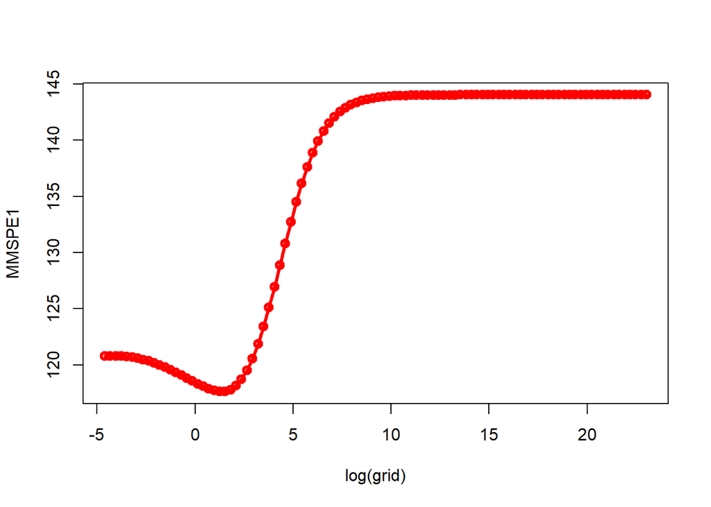

```r
plot(log(grid), MMSPE1, type="o", col = "red", lwd = 3)
```

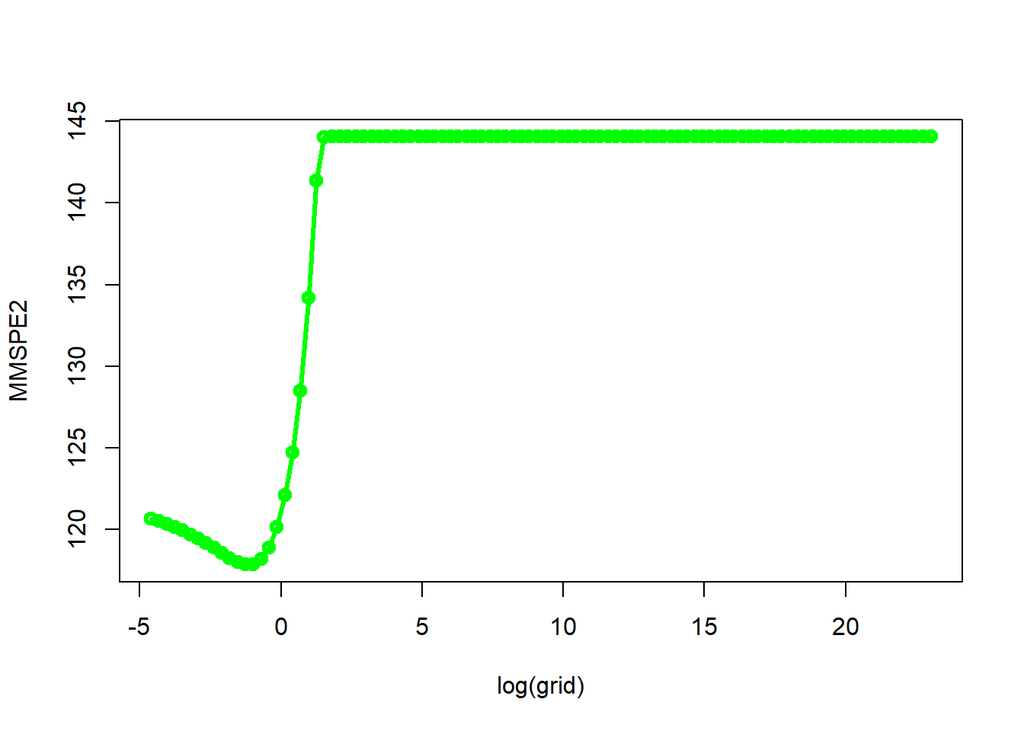

```r
plot(log(grid), MMSPE2, type="o", col = "green", lwd = 3)
```

```r
lam <- grid[which.min(MMSPE1)]
coeff <- predict(model1, s = lam , type = "coefficients", newx = xtrain)
coeff
```

```
## 33 x 1 sparse Matrix of class "dgCMatrix"
##                                      1
## (Intercept)              -9.121156e+02
## DESPC                    -1.284828e-01
## DESSC                     1.448016e-01
## DESWC                    -1.233909e-02
## DESPL                    -4.809685e-01
## DESPLd                   -3.473139e-01
## DESSL                    -6.294488e-01
## DESSLd                   -2.793286e-02
## DESWLsy                  -3.053909e+01
## DESWLsyd                  3.987407e+01
## DESWLlt                  -2.005419e+00
## DESWLltd                 -1.433854e+01
## Year                      5.025140e-01
## PCNARz                   -2.295256e+00
## PCSYNz                   -4.828960e+00
## PCCNCz                    2.587706e+00
## PCREFz                   -2.309769e+00
## PCDCz                    -6.416599e-01
## PCVERBz                  -4.179479e+00
## PCCONNz                  -6.184118e-01
## PCTEMPz                  -2.365708e-01
## Readabilityfleschkincaid -1.261812e-01
## Readabilityfog           -6.761982e-01
## industry3                -1.259697e-01
## firmsize                  2.039706e+00
## RDFRE                     3.538048e-02
## RDFKGL                    7.251799e-01
## Posemo                   -8.213777e-01
## Negemo                    2.279262e+00
## Negativity_Freq           4.606287e-01
## positivity_Freq           1.289264e-01
## ForwardLooking_Freq       1.953242e-01
## Uncertainty_Freq         -2.012428e-03
```

```r
coef_lasso <- coef(model2, s=grid[which.min(MMSPE2)], nonzero = T)
coef_lasso
```

```
## 33 x 1 sparse Matrix of class "dgCMatrix"
##                                      1
## (Intercept)              -930.20574760
## DESPC                      -0.07850372
## DESSC                       0.09219275
## DESWC                      -0.01039451
## DESPL                      -0.44881868
## DESPLd                     -0.30876402
## DESSL                      -0.29089863
## DESSLd                     -0.02938453
## DESWLsy                   -16.73790361
## DESWLsyd                   38.62738292
## DESWLlt                    -1.72075194
## DESWLltd                  -14.10663042
## Year                        0.49937430
## PCNARz                     -2.12862378
## PCSYNz                     -4.48416038
## PCCNCz                      2.54464359
## PCREFz                     -2.22819695
## PCDCz                      -0.61152130
## PCVERBz                    -4.02625534
## PCCONNz                    -0.57782758
## PCTEMPz                    -0.22299028
## Readabilityfleschkincaid   -0.11253724
## Readabilityfog             -0.67926009
## industry3                  -0.12050413
## firmsize                    2.02808472
## RDFRE                       0.07457697
## RDFKGL                      .
## Posemo                     -0.80655120
## Negemo                      2.30328778
## Negativity_Freq             0.45716529
## positivity_Freq             0.12350204
## ForwardLooking_Freq         0.19256835
## Uncertainty_Freq            .
```

RDFKGL variable and Uncertainty_Freq variable were dropped in Lasso because they are not a good predictors.

### 7. Now, I will replace lambda by optimal value, and find mean and sqrt(var) of RMSPE for Ridge and LASSO.

```r
remove(list = ls())
CSRdata <- read.csv("CSRScore.csv")
df <- CSRdata
df <- df[complete.cases(df), ]

X <- model.matrix(CSR~., df)[,-1]
y <- df$CSR

library(glmnet)
grid = 10^seq(10, -2, length = 100)
model <- glmnet(X, y, alpha = 0, lambda = grid)
```

```r
library(glmnet)

#df <- df[complete.cases(df), ]

RMSPE1 <- c()#LPM/Ridge
RMSPE2 <- c()#LPM/LASSO


for(i in 1:500){
ind <- sample(nrow(df), nrow(df), replace = TRUE)
ind <- unique(ind)

train <- df[ind, ]
xtrain <- model.matrix(CSR~., train)[,-1]
ytrain <- df[ind, 1]

test <- df[-ind, ]
xtest <- model.matrix(CSR~., test)[,-1]
ytest <- df[-ind, 1]



model1 <- glmnet(xtrain, ytrain, alpha = 0, lambda = 3.511192, thresh = 1e-12,)#LPM/Ridge
model2 <- glmnet(xtrain, ytrain, alpha = 1, lambda = 0.2848036, thresh = 1e-12,)#LPM/LASSO


yhat1 <- predict(model1, s = 3.511192, newx = xtest)
yhat2 <- predict(model2, s = 0.2848036, newx = xtest)

RMSPE1[i] <- sqrt(mean((yhat1 - ytest)^2))
RMSPE2[i] <- sqrt(mean((yhat2 - ytest)^2))
}

mean(RMSPE1)
```

```
## [1] 10.86428
```

```r
mean(RMSPE2)
```

```
## [1] 10.87879
```

```r
sqrt(var(RMSPE1)*500/499)
```

```
## [1] 0.3231296
```

```r
sqrt(var(RMSPE2)*500/499)
```

```
## [1] 0.3229803
```

### 8. I add polynomials and/or interactions into the Ridge and LASSO models.

```r
remove(list = ls())
CSRdata <- read.csv("CSRScore.csv")
df <- CSRdata
df <- df[complete.cases(df), ]

X <- model.matrix(CSR~., df)[,-1]
y <- df$CSR

library(glmnet)
grid = 10^seq(10, -2, length = 100)
model <- glmnet(X, y, alpha = 0, lambda = grid)
```

Now I add 2nd order polynomials for the variables of interests.Note: I try all the variables but it did not go through because of the size. By adding the interaction, I increase the number of variables from 33 to 137.

```r
# Creating variables for the 2nd model
m <- as.matrix(df[, 13:25])
M <- poly(m, degree = 2, raw=TRUE)

# Adding them to the original data
newdf <- cbind(df, M)
#str(newdf)
```

```r
X <- model.matrix(CSR~., newdf)[,-1]
y <- newdf$CSR

library(glmnet)
grid = 10^seq(10, -2, length = 100)
model <- glmnet(X, y, alpha = 0, lambda = grid)
```

```r
## I have a problem with this script and I am still searching to solve it.
#library(glmnet)
#newdf <- newdf[complete.cases(newdf), ]
#grid = 10^seq(10, -2, length = 100)

#MSPE1 <- c()#LPM/Ridge
#MMSPE1 <- c()#LPM/Ridge
#MSPE2 <- c()#LPM/LASSO
#MMSPE2 <- c()#LPM/LASSO


#for(i in 1:length(grid)){
#for(j in 1:10){
#set.seed(j)

#ind <- sample(nrow(newdf), nrow(newdf), replace = TRUE)
####ind <- unique(newdf)

#train <- newdf[ind, ]
#xtrain <- model.matrix(CSR~., train)[,-1]
#ytrain <- newdf[ind, 1]

#test <- newdf[-ind, ]
#xtest <- model.matrix(CSR~., test)[,-1]
#ytest <- newdf[-ind, 1]


#model1 <- glmnet(xtrain, ytrain, alpha = 0, lambda = grid[i], thresh = 1e-12,)#LPM/Ridge
#model2 <- glmnet(xtrain, ytrain, alpha = 1, lambda = grid[i], thresh = 1e-12,)#LPM/LASSO


#yhat1 <- predict(model1, s = grid[i], newx = xtest)
#yhat2 <- predict(model2, s = grid[i], newx = xtest)



#MSPE1[j] <- mean((yhat1 - ytest)^2)
#MSPE2[j] <- mean((yhat2 - ytest)^2)
#}
#MMSPE1[i] <- mean(MSPE1)
#MMSPE2[i] <- mean(MSPE2)
#}

#min(MMSPE1)
#min(MMSPE2)
```

```r
#grid[which.min(MMSPE1)]
#grid[which.min(MMSPE2)]
```

```r
#lam <- grid[which.min(MMSPE1)]
#coeff <- predict(model1, s = lam , type = "coefficients", newx = xtrain)
#coeff
```

```r
#coef_lasso <- coef(model2, s=grid[which.min(MMSPE2)], nonzero = T)
#coef_lasso
```

```r
# library(glmnet)
#
# RMSPE1 <- c()#LPM/Ridge
# RMSPE2 <- c()#LPM/LASSO
#
#
# for(i in 1:500){
# ind <- sample(nrow(df), nrow(df), replace = TRUE)
# ind <- unique(ind)
#
# train <- df[ind, ]
# xtrain <- model.matrix(CSR~., train)[,-1]
# ytrain <- df[ind, 1]
#
# test <- df[-ind, ]
# xtest <- model.matrix(CSR~., test)[,-1]
# ytest <- df[-ind, 1]
#
#
#
# model1 <- glmnet(xtrain, ytrain, alpha = 0, lambda = 3.511192, thresh = 1e-12,)#LPM/Ridge
# model2 <- glmnet(xtrain, ytrain, alpha = 1, lambda = 0.2848036, thresh = 1e-12,)#LPM/LASSO
#
#
# yhat1 <- predict(model1, s = 3.511192, newx = xtest)
# yhat2 <- predict(model2, s = 0.2848036, newx = xtest)
#
# RMSPE1[i] <- sqrt(mean((yhat1 - ytest)^2))
# RMSPE2[i] <- sqrt(mean((yhat2 - ytest)^2))
# }
#
# mean(RMSPE1)
# mean(RMSPE2)
#
# sqrt(var(RMSPE1)*500/499)
# sqrt(var(RMSPE2)*500/499)
```

```r
# library(glmnet)
#
# grid = 10^seq(10, -2, length = 100)
#
# RMSPE1 <- c()#LPM/Ridge
# RMSPE2 <- c()#LPM/LASSO
#
# for(i in 1:length(grid)){
# for(j in 1:100){
# set.seed(j)
#
# ind <- sample(nrow(newdf), nrow(newdf), replace = TRUE)
# #ind <- unique(ind)
# train <- newdf[ind, ]
#
# xtrain <- model.matrix(CSR~., train)[,-1]
# ytrain <- newdf[ind, 1]
# test <- newdf[-ind, ]
# xtest <- model.matrix(CSR~., test)[,-1]
# ytest <- newdf[-ind, 1]
#
#
#
# model1 <- glmnet(xtrain, ytrain, alpha = 0, lambda = 3.511192, thresh = 1e-12,)#LPM/Ridge
# model2 <- glmnet(xtrain, ytrain, alpha = 1, lambda = 4.641589, thresh = 1e-12,)#LPM/LASSO
#
#
# yhat1 <- predict(model1, s = grid[i], newx = xtest)
# yhat2 <- predict(model2, s = grid[i], newx = xtest)
#
#
#
# RMSPE1[i] <- sqrt(mean((yhat1 - ytest)^2))
# RMSPE2[i] <- sqrt(mean((yhat2 - ytest)^2))
# }
# }
#
# mean(RMSPE1)
# mean(RMSPE2)
# sqrt(var(RMSPE1) * (length(grid) / (length(grid) - 1)))
# sqrt(var(RMSPE2) * (length(grid) / (length(grid) - 1)))
```

### 11. Non- parametric models: OLS vs.CART (regression tree - rpart) vs. Bagging vs. RF vs. Boosting. OLS is a parametric model and I added it to just compare it other Non- parametric models.

```r
remove(list = ls())
CSRdata <- read.csv("CSRScore.csv")
df <- CSRdata
df <- df[complete.cases(df), ]
```

```r
library(randomForest)
library(rpart)
library(gbm)
n <- 10#chagne n t0 100
B <- 1000
RMSPE1 <- c()
RMSPE2 <- c()
RMSPE3 <- c()
RMSPE4 <- c()
RMSPE5 <- c()

for (i in 1:n) {
ind <- sample(nrow(df), nrow(df), replace = TRUE)
train <- df[ind, ]
test <- df[-ind, ]

p = ncol(train)-1

model1 <- lm(CSR~., data = train) #OLS
model2 <- rpart(CSR~., data =train) # Single Tree
model3 <- randomForest(CSR~., ntree = B, mtry = p, data = train) #Bagged
model4 <- randomForest(CSR~., ntree = B, data = train) # RF
model5 <- gbm(CSR~., distribution="gaussian", n.trees = B, data=train, shrinkage = 0.1, bag.fraction = 1) # Boosting


yhat1 <- predict(model1, test)
yhat2 <- predict(model2, test)
yhat3 <- predict(model3, test)
yhat4 <- predict(model4, test)
yhat5 <- predict(model5, n.trees = B, test)

RMSPE1[i] <- sqrt(mean((test$CSR - yhat1)^2))
RMSPE2[i] <- sqrt(mean((test$CSR - yhat2)^2))
RMSPE3[i] <- sqrt(mean((test$CSR - yhat3)^2))
RMSPE4[i] <- sqrt(mean((test$CSR - yhat4)^2))
RMSPE5[i] <- sqrt(mean((test$CSR - yhat5)^2))
}

mean(RMSPE1)
```

```
## [1] 11.03216
```

```r
mean(RMSPE2)
```

```
## [1] 12.32458
```

```r
mean(RMSPE3)
```

```
## [1] 10.2752
```

```r
mean(RMSPE4)
```

```
## [1] 10.25295
```

```r
mean(RMSPE5)
```

```
## [1] 10.6794
```

```r
sqrt(var(RMSPE1) * n / (n - 1))
```

```
## [1] 0.5133372
```

```r
sqrt(var(RMSPE2) * n / (n - 1))
```

```
## [1] 0.6433621
```

```r
sqrt(var(RMSPE3) * n / (n - 1))
```

```
## [1] 0.3123327
```

```r
sqrt(var(RMSPE4) * n / (n - 1))
```

```
## [1] 0.382608
```

```r
sqrt(var(RMSPE5) * n / (n - 1))
```

```
## [1] 0.6419769
```

### 13. Identify the most important predictors.

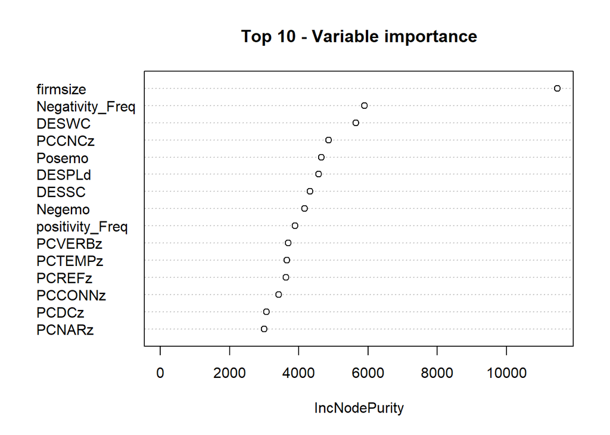

```r
varImpPlot(model4, sort = T, n.var = 15, main = "Top 10 - Variable importance")
```

```r
importance(model4)
```

```
##                          IncNodePurity
## DESPC                         2827.115
## DESSC                         4325.523
## DESWC                         5650.400
## DESPL                         2450.989
## DESPLd                        4567.734
## DESSL                         2430.672
## DESSLd                        2391.210
## DESWLsy                       1659.676
## DESWLsyd                      2620.084
## DESWLlt                       1814.529
## DESWLltd                      2318.720
## Year                          1297.655
## PCNARz                        3003.213
## PCSYNz                        2934.117
## PCCNCz                        4855.133
## PCREFz                        3628.741
## PCDCz                         3057.742
## PCVERBz                       3686.732
## PCCONNz                       3420.805
## PCTEMPz                       3658.756
## Readabilityfleschkincaid      2401.833
## Readabilityfog                2354.172
## industry3                     2334.139
## firmsize                     11466.556
## RDFRE                         1812.619
## RDFKGL                        1735.143
## Posemo                        4646.104
## Negemo                        4162.714
## Negativity_Freq               5891.974
## positivity_Freq               3894.662
## ForwardLooking_Freq           2314.824
## Uncertainty_Freq              1797.811
```

```r
varUsed(model4)#this can be used to find out which predictor variables are actually used in RF model.
```

```
##  [1]  6375  7146  8403  7771  8650  7326  7727  6485  7492  6888  7454  5808
## [13]  8276  7824  9481  8065  8762  8627  9282  8575  7434  7627  6271 11312
## [25]  6718  6626  9417  7047  6397  7961  7173  6145
```

### 1. Classification problem (“excellent” and “not excellent” performance)

```r
remove(list = ls())
CSRdata <- read.csv("CSRScore.csv")
df <- CSRdata
df <- df[complete.cases(df), ]
```

A Company has excellent CSR performance if its CSR performance above 75%. However, a company does not have excellent CSR performance if its CSR performance below 75%.

```r
quantile(df$CSR, probs = c(0.75, 0.25))
```

```
##      75%      25%
## 50.82640 33.09217
```

```r
CSRdata <- df[complete.cases(CSRdata), ]


df <- CSRdata[, -1] #Dropping "CSR"
df$y <- ifelse(CSRdata$CSR > 50.82640, 1, 0) #groups outcome variable CSR into “excellent” and “not excellent” categories.
table(df$y)
```

```
##
##   0   1
## 584 183
```

Clear, we have imbalanced data problem. It is 76% and 23%, it is not a balanced data because it is not around the range 60% 40%.

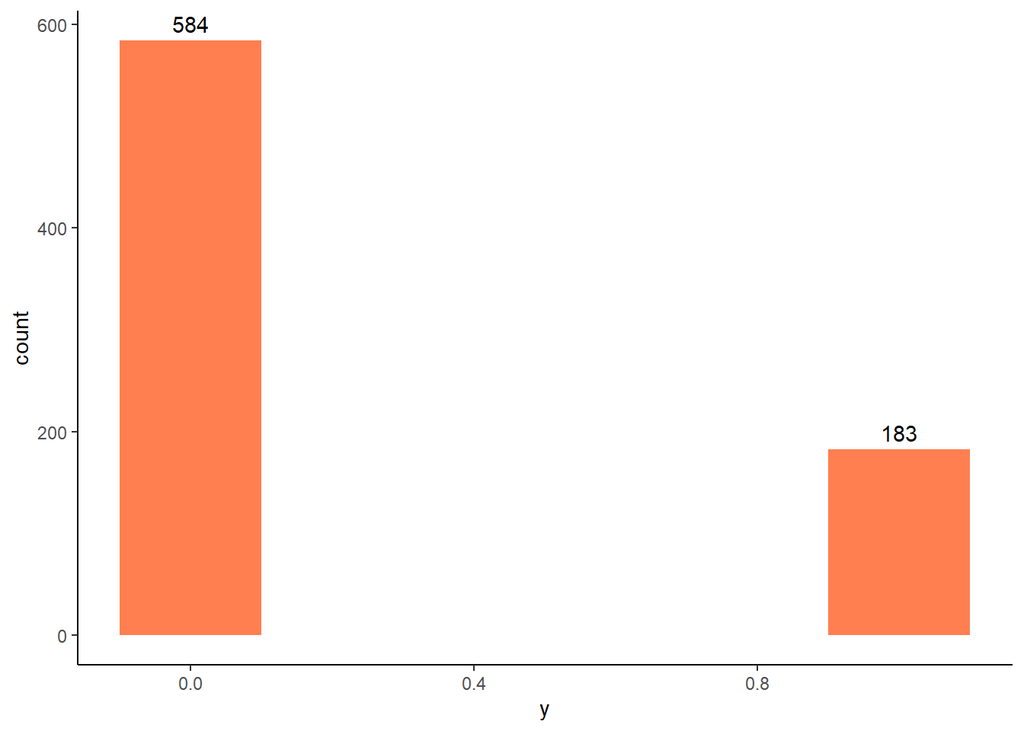

```r
library(ggplot2)
ggplot(df, aes(x = y)) +
geom_bar(width=0.2, fill = "coral") +
geom_text(stat='count', aes(label=stat(count)), vjust=-0.5) +
theme_classic()
```

Now, I will handle imbalanced data problem by using SMOTE.

```r
library(DMwR)
df$y <- as.factor(df$y)# SMOTE requires the outcome variable to be a factor variable

df <- SMOTE(y ~., df, perc.over =100, perc.under=200)
table(df$y)
```

```
##
##   0   1
## 357 366
```

```r
dim(df)
```

[output not shown]

```r
library(gplots)
library(PASWR)
library(ROCR)
library(rpart)
library(randomForest)
library(gbm)


df <- df[complete.cases(df), ]
df$d <- df$y
df$y <- as.integer(df$y)
df$y[df$y==1] <- 0
df$y[df$y==2] <- 1


n <- 20
B <- 1000
AUC1 <- c()
AUC2 <- c()
AUC3 <- c()
AUC4 <- c()

for (i in 1:n) {
  ind <- sample(nrow(df), nrow(df), replace = TRUE)
  train <- df[ind, ]
  test <- df[-ind, ]

  p = ncol(train)-2 #deleting survived and d columns. I need only 5 features.

  model1 <- rpart(y~., data=train[,-34], method = "class")#single tree
  model2 <- randomForest(d~., ntree = B, mtry = p, data = train[, -33]) #Bagged (-33 to drop y)
  model3 <- randomForest(d~., ntree = B, data = train[, -33]) # RF
  model4 <- gbm(y~., data=train[,-34], n.trees = B, distribution = "bernoulli") # Boosting

  phat1 <- predict(model1, test[,-34], type = "prob")
  phat2 <- predict(model2, test[,-33], type = "prob")
  phat3 <- predict(model3, test[,-33], type = "prob")
  phat4 <- predict(model4, n.trees = B, test[,-34], type = "response")

  #AUC1
  pred_rocr1 <- prediction(phat1[,2], test$y)
  auc_ROCR1 <- performance(pred_rocr1, measure = "auc")
  AUC1[i] <- auc_ROCR1@y.values[[1]]

  #AUC2
  pred_rocr2 <- prediction(phat2[,2], test$d)
  auc_ROCR2 <- performance(pred_rocr2, measure = "auc")
  AUC2[i] <- auc_ROCR2@y.values[[1]]

  #AUC3
  pred_rocr3 <- prediction(phat3[,2], test$d)
  auc_ROCR3 <- performance(pred_rocr3, measure = "auc")
  AUC3[i] <- auc_ROCR3@y.values[[1]]

  #AUC4
  pred_rocr4 <- prediction(phat4, test$y)
  auc_ROCR4 <- performance(pred_rocr4, measure = "auc")
  AUC4[i] <- auc_ROCR4@y.values[[1]]
}

mean(AUC1)
```

```
## [1] 0.7678275
```

```r
mean(AUC2)
```

```
## [1] 0.9275776
```

```r
mean(AUC3)
```

```
## [1] 0.9397608
```

```r
mean(AUC4)
```

```
## [1] 0.8612051
```

```r
sqrt(var(AUC1) * n / (n - 1))
```

```
## [1] 0.0318574
```

```r
sqrt(var(AUC2) * n / (n - 1))
```

```
## [1] 0.01719937
```

```r
sqrt(var(AUC3) * n / (n - 1))
```

```
## [1] 0.0133685
```

```r
sqrt(var(AUC4) * n / (n - 1))
```

```
## [1] 0.01766154
```

### 3. **Parametric models**: LPM, Logistic, LPM/Logistic models with Ridge and LASSO.

## 4. LPM and Logistic

```r
remove(list = ls())
CSRdata <- read.csv("CSRScore.csv")
df <- CSRdata
df <- df[complete.cases(df), ]


CSRdata <- df[complete.cases(CSRdata), ]
df <- CSRdata[, -1] #Dropping "CSR"
df$y <- ifelse(CSRdata$CSR > 50.82640, 1, 0) #groups outcome variable CSR into “excellent” and “not excellent” categories.
table(df$y)
```

```
##
##   0   1
## 584 183
```

```r
#Now, I will handle imbalanced data problem by using SMOTE.
library(DMwR)
df$y <- as.factor(df$y)
df <- SMOTE(y ~., df, perc.over =100, perc.under=200)
table(df$y)
```

```
##
##   0   1
## 352 366
```

```r
library(PASWR)
library(ROCR)
library(rpart)

df$y <- as.integer(df$y)
df$y[df$y==1] <- 0
df$y[df$y==2] <- 1

n <- 500
AUC1 <- c()
AUC2 <- c()

for (i in 1:n) {
ind <- sample(nrow(df), nrow(df), replace = TRUE)
train <- df[ind, ]
test <- df[-ind, ]

model1 <- lm(y~., data=train)
model2 <- glm(y~.,data = train, family = binomial)


phat1 <- predict(model1, test, type = "response")
phat2 <- predict(model2, test, type = "response")

#AUC1
pred_rocr1 <- prediction(phat1, test$y)
auc_ROCR1 <- performance(pred_rocr1, measure = "auc")
AUC1[i] <- auc_ROCR1@y.values[[1]]

#AUC2
pred_rocr2 <- prediction(phat2, test$y)
auc_ROCR2 <- performance(pred_rocr2, measure = "auc")
AUC2[i] <- auc_ROCR2@y.values[[1]]
}
mean(AUC1)
```

```
## [1] 0.7287514
```

```r
mean(AUC2)
```

```
## [1] 0.7263283
```

```r
sqrt(var(AUC1) * n / (n - 1))
```

```
## [1] 0.02544586
```

```r
sqrt(var(AUC2) * n / (n - 1))
```

```
## [1] 0.02595875
```

### 5. Parametric models: LPM and Logistic models with Ridge and LASSO.

## **First, let us find the optimal value of lambda**

```r
remove(list = ls())
CSRdata <- read.csv("CSRScore.csv")
df <- CSRdata
df <- df[complete.cases(df), ]


CSRdata <- df[complete.cases(CSRdata), ]
df <- CSRdata[, -1] #Dropping "CSR"
df$y <- ifelse(CSRdata$CSR > 50.82640, 1, 0) #groups outcome variable CSR into “excellent” and “not excellent” categories.
table(df$y)
```

```
##
##   0   1
## 584 183
```

```r
library(DMwR)
df$y <- as.factor(df$y)# SMOTE requires the outcome variable to be a factor variable
df <- SMOTE(y ~., df, perc.over =100, perc.under=200)
table(df$y)
```

```
##
##   0   1
## 356 366
```

```r
library(PASWR)
library(ROCR)
library(rpart)
library(glmnet)

df <- df[complete.cases(df), ]
df$y <- as.integer(df$y)
#df$y[df$y==1] <- 0
#df$y[df$y==2] <- 1


grid = 10^seq(10, -2, length = 100)
AUC3 <- c() #LPM/Ridge
MAUC3<- c() #LPM/Ridge

AUC4 <- c() #LPM/LASSO
MAUC4 <- c() #LPM/LASSO

AUC5 <- c() #Logistic/Ridge
MAUC5 <- c() #Logistic/Ridge

AUC6 <- c() #Logistic/LASSO
MAUC6 <- c() #Logistic/LASSO

for(i in 1:length(grid)){
for(j in 1:100){
set.seed(j)
ind <- sample(nrow(df), nrow(df), replace = TRUE)
#ind <- unique(ind)

train <- df[ind, ]
xtrain <- model.matrix(y~., train)[,-33]
ytrain <- df[ind, 33]

test <- df[-ind, ]
xtest <- model.matrix(y~., test)[,-33]
ytest <- df[-ind, 33]


model3 <- glmnet(xtrain, ytrain, alpha = 0, lambda = grid[i], thresh = 1e-12,)#LPM/Ridge
model4 <- glmnet(xtrain, ytrain, alpha = 1, lambda = grid[i], thresh = 1e-12,)#LPM/LASSO
model5 <- glmnet(xtrain, ytrain, alpha = 0, lambda = grid[i], thresh = 1e-12, family = "binomial") #Logistic/Ridge
model6 <- glmnet(xtrain, ytrain, alpha = 1, lambda = grid[i], thresh = 1e-12, family = "binomial") #Logistic/LASSO


phat3 <- predict(model3, s = grid[i], newx = xtest, type = "response")
phat4 <- predict(model4, s = grid[i], newx = xtest, type = "response")
phat5 <- predict(model5, s = grid[i], newx = xtest, type = "response")
phat6 <- predict(model6, s = grid[i], newx = xtest, type = "response")


#AUC3
pred3 <- prediction(phat3, ytest)
auc3 <- performance(pred3, measure = "auc")
AUC3[j] <- auc3@y.values[[1]]

#AUC4
pred4 <- prediction(phat4, ytest)
auc4 <- performance(pred4, measure = "auc")
AUC4[j] <- auc4@y.values[[1]]

#AUC5
pred5 <- prediction(phat5, ytest)
auc5 <- performance(pred5, measure = "auc")
AUC5[j] <- auc5@y.values[[1]]

#AUC6
pred6 <- prediction(phat6, ytest)
auc6 <- performance(pred6, measure = "auc")
AUC6[j] <- auc6@y.values[[1]]
}

MAUC3[i] <- mean(AUC3)
MAUC4[i] <- mean(AUC4)
MAUC5[i] <- mean(AUC5)
MAUC6[i] <- mean(AUC6)
}

max(MAUC3)
```

```
## [1] 0.7171108
```

```r
max(MAUC4)
```

```
## [1] 0.714883
```

```r
max(MAUC5)
```

```
## [1] 0.7175035
```

```r
max(MAUC6)
```

```
## [1] 0.7151573
```

```r
grid[which.max(MAUC3)]
```

```
## [1] 0.04037017
```

```r
grid[which.max(MAUC4)]
```

```
## [1] 0.01
```

```r
grid[which.max(MAUC5)]
```

```
## [1] 0.0231013
```

```r
grid[which.max(MAUC6)]
```

```
## [1] 0.01
```

```r
remove(list = ls())
CSRdata <- read.csv("CSRScore.csv")
df <- CSRdata
df <- df[complete.cases(df), ]


CSRdata <- df[complete.cases(CSRdata), ]
df <- CSRdata[, -1] #Dropping "CSR"
df$y <- ifelse(CSRdata$CSR > 50.82640, 1, 0) #groups outcome variable CSR into “excellent” and “not excellent” categories.
table(df$y)
```

```
##
##   0   1
## 584 183
```

```r
library(DMwR)
df$y <- as.factor(df$y)# SMOTE requires the outcome variable to be a factor variable
df <- SMOTE(y ~., df, perc.over =100, perc.under=200)
table(df$y)
```

```
##
##   0   1
## 354 366
```

```r
library(PASWR)
library(ROCR)
library(rpart)
library(glmnet)

df <- df[complete.cases(df), ]
df$y <- as.integer(df$y)

AUC3 <- c() #LPM/Ridge
MAUC3<- c() #LPM/Ridge

AUC4 <- c() #LPM/LASSO
MAUC4 <- c() #LPM/LASSO

AUC5 <- c() #Logistic/Ridge
MAUC5 <- c() #Logistic/Ridge

AUC6 <- c() #Logistic/LASSO
MAUC6 <- c() #Logistic/LASSO


for(i in 1:500){
ind <- sample(nrow(df), nrow(df), replace = TRUE)
ind <- unique(ind)
train <- df[ind, ]
xtrain <- model.matrix(y~., train)[,-33]
ytrain <- df[ind, 33]
test <- df[-ind, ]
xtest <- model.matrix(y~., test)[,-33]
ytest <- df[-ind, 33]


model3 <- glmnet(xtrain, ytrain, alpha = 0, lambda = 0.01321941, thresh = 1e-12,)#LPM/Ridge
model4 <- glmnet(xtrain, ytrain, alpha = 1, lambda = 0.0231013, thresh = 1e-12,)#LPM/LASSO
model5 <- glmnet(xtrain, ytrain, alpha = 0, lambda = 0.01, thresh = 1e-12, family = "binomial") #Logistic/Ridge
model6 <- glmnet(xtrain, ytrain, alpha = 1, lambda = 0.0231013, thresh = 1e-12, family = "binomial") #Logistic/LASSO


phat3 <- predict(model3, s = 0.01, newx = xtest, type = "response")
phat4 <- predict(model4, s = 0.01, newx = xtest, type = "response")
phat5 <- predict(model5, s = 0.01, newx = xtest, type = "response")
phat6 <- predict(model6, s = 0.01, newx = xtest, type = "response")


#AUC3
pred3 <- prediction(phat3, ytest)
auc3 <- performance(pred3, measure = "auc")
AUC3[i] <- auc3@y.values[[1]]

#AUC4
pred4 <- prediction(phat4, ytest)
auc4 <- performance(pred4, measure = "auc")
AUC4[i] <- auc4@y.values[[1]]

#AUC5
pred5 <- prediction(phat5, ytest)
auc5 <- performance(pred5, measure = "auc")
AUC5[i] <- auc5@y.values[[1]]

#AUC6
pred6 <- prediction(phat6, ytest)
auc6 <- performance(pred6, measure = "auc")
AUC6[i] <- auc6@y.values[[1]]
}



mean(AUC3)
```

```
## [1] 0.7443887
```

```r
mean(AUC4)
```

```
## [1] 0.7379463
```

```r
mean(AUC5)
```

```
## [1] 0.7436405
```

```r
mean(AUC6)
```

```
## [1] 0.737323
```

```r
sqrt(var(AUC3)*500/499)
```

```
## [1] 0.02293665
```

```r
sqrt(var(AUC4)*500/499)
```

```
## [1] 0.02318369
```

```r
sqrt(var(AUC5)*500/499)
```

```
## [1] 0.02314522
```

```r
sqrt(var(AUC6)*500/499)
```

```
## [1] 0.02331032
```

### 7. I add polynomials and/or interactions into the Ridge and LASSO models.

First, I will find the optimal value of lambda.

```r
remove(list = ls())
CSRdata <- read.csv("CSRScore.csv")
df <- CSRdata
df <- df[complete.cases(df), ]


CSRdata <- df[complete.cases(CSRdata), ]
df <- CSRdata[, -1] #Dropping "medv"
df$y <- ifelse(CSRdata$CSR > 50.82640, 1, 0) #groups outcome variable CSR into “excellent” and “not excellent” categories.
table(df$y)
```

```
##
##   0   1
## 584 183
```

```r
library(DMwR)
df$y <- as.factor(df$y)# SMOTE requires the outcome variable to be a factor variable
df <- SMOTE(y ~., df, perc.over =100, perc.under=200)
table(df$y)
```

```
##
##   0   1
## 355 366
```

```r
# Creating variables for the 2nd model
m <- as.matrix(df[, 13:25])
M <- poly(m, degree = 2, raw=TRUE)

# Adding them to the original data
newdf <- cbind(df, M)
#str(newdf)
```

```r
library(PASWR)
library(ROCR)
library(rpart)
library(glmnet)

newdf <- newdf[complete.cases(newdf), ]
newdf$y <- as.integer(newdf$y)
#df$y[df$y==1] <- 0
#df$y[df$y==2] <- 1


grid = 10^seq(10, -2, length = 100)
AUC3 <- c() #LPM/Ridge
MAUC3<- c() #LPM/Ridge

AUC4 <- c() #LPM/LASSO
MAUC4 <- c() #LPM/LASSO

AUC5 <- c() #Logistic/Ridge
MAUC5 <- c() #Logistic/Ridge

AUC6 <- c() #Logistic/LASSO
MAUC6 <- c() #Logistic/LASSO

for(i in 1:length(grid)){
for(j in 1:100){
set.seed(j)
ind <- sample(nrow(newdf), nrow(newdf), replace = TRUE)
#ind <- unique(ind)

train <- newdf[ind, ]
xtrain <- model.matrix(y~., train)[,-33]
ytrain <- newdf[ind, 33]

test <- newdf[-ind, ]
xtest <- model.matrix(y~., test)[,-33]
ytest <- newdf[-ind, 33]


model3 <- glmnet(xtrain, ytrain, alpha = 0, lambda = grid[i], thresh = 1e-12,)#LPM/Ridge
model4 <- glmnet(xtrain, ytrain, alpha = 1, lambda = grid[i], thresh = 1e-12,)#LPM/LASSO
model5 <- glmnet(xtrain, ytrain, alpha = 0, lambda = grid[i], thresh = 1e-12, family = "binomial") #Logistic/Ridge
model6 <- glmnet(xtrain, ytrain, alpha = 1, lambda = grid[i], thresh = 1e-12, family = "binomial") #Logistic/LASSO


phat3 <- predict(model3, s = grid[i], newx = xtest, type = "response")
phat4 <- predict(model4, s = grid[i], newx = xtest, type = "response")
phat5 <- predict(model5, s = grid[i], newx = xtest, type = "response")
phat6 <- predict(model6, s = grid[i], newx = xtest, type = "response")


#AUC3
pred3 <- prediction(phat3, ytest)
auc3 <- performance(pred3, measure = "auc")
AUC3[j] <- auc3@y.values[[1]]

#AUC4
pred4 <- prediction(phat4, ytest)
auc4 <- performance(pred4, measure = "auc")
AUC4[j] <- auc4@y.values[[1]]

#AUC5
pred5 <- prediction(phat5, ytest)
auc5 <- performance(pred5, measure = "auc")
AUC5[j] <- auc5@y.values[[1]]

#AUC6
pred6 <- prediction(phat6, ytest)
auc6 <- performance(pred6, measure = "auc")
AUC6[j] <- auc6@y.values[[1]]
}

MAUC3[i] <- mean(AUC3)
MAUC4[i] <- mean(AUC4)
MAUC5[i] <- mean(AUC5)
MAUC6[i] <- mean(AUC6)
}

max(MAUC3)
```

```
## [1] 0.7513766
```

```r
max(MAUC4)
```

```
## [1] 0.7290038
```

```r
max(MAUC5)
```

```
## [1] 0.7432101
```

```r
max(MAUC6)
```

```
## [1] 0.7282741
```

```r
grid[which.max(MAUC3)]
```

```
## [1] 0.01
```

```r
grid[which.max(MAUC4)]
```

```
## [1] 0.01
```

```r
grid[which.max(MAUC5)]
```

```
## [1] 0.01
```

```r
grid[which.max(MAUC6)]
```

```
## [1] 0.01
```

### 8. Now, I will replace lambda by the optimal value of lambda, and find mean and sqrt(var) of RMSPE for Ridge and LASSO with interaction.

```r
remove(list = ls())
CSRdata <- read.csv("CSRScore.csv")
df <- CSRdata
df <- df[complete.cases(df), ]


CSRdata <- df[complete.cases(CSRdata), ]
df <- CSRdata[, -1] #Dropping "CSR"
df$y <- ifelse(CSRdata$CSR > 50.82640, 1, 0) #groups outcome variable CSR into “excellent” and “not excellent” categories.
table(df$y)
```

```
##
##   0   1
## 584 183
```

```r
library(DMwR)
df$y <- as.factor(df$y)# SMOTE requires the outcome variable to be a factor variable
df <- SMOTE(y ~., df, perc.over =100, perc.under=200)
table(df$y)
```

```
##
##   0   1
## 354 366
```

```r
# Creating variables for the 2nd model
m <- as.matrix(df[, 13:25])
M <- poly(m, degree = 2, raw=TRUE)

# Adding them to the original data
newdf <- cbind(df, M)
#str(newdf)
```

```r
library(PASWR)
library(ROCR)
library(rpart)
library(glmnet)

newdf <- newdf[complete.cases(newdf), ]
newdf$y <- as.integer(newdf$y)

AUC3 <- c() #LPM/Ridge
MAUC3<- c() #LPM/Ridge

AUC4 <- c() #LPM/LASSO
MAUC4 <- c() #LPM/LASSO

AUC5 <- c() #Logistic/Ridge
MAUC5 <- c() #Logistic/Ridge

AUC6 <- c() #Logistic/LASSO
MAUC6 <- c() #Logistic/LASSO


for(i in 1:500){
ind <- sample(nrow(newdf), nrow(newdf), replace = TRUE)
ind <- unique(ind)
train <- newdf[ind, ]
xtrain <- model.matrix(y~., train)[,-33]
ytrain <- newdf[ind, 33]
test <- newdf[-ind, ]
xtest <- model.matrix(y~., test)[,-33]
ytest <- newdf[-ind, 33]


model3 <- glmnet(xtrain, ytrain, alpha = 0, lambda = 0.01, thresh = 1e-12,)#LPM/Ridge
model4 <- glmnet(xtrain, ytrain, alpha = 1, lambda = 0.01, thresh = 1e-12,)#LPM/LASSO
model5 <- glmnet(xtrain, ytrain, alpha = 0, lambda = 0.01, thresh = 1e-12, family = "binomial") #Logistic/Ridge
model6 <- glmnet(xtrain, ytrain, alpha = 1, lambda = 0.01, thresh = 1e-12, family = "binomial") #Logistic/LASSO


phat3 <- predict(model3, s = 0.01, newx = xtest, type = "response")
phat4 <- predict(model4, s = 0.01, newx = xtest, type = "response")
phat5 <- predict(model5, s = 0.01, newx = xtest, type = "response")
phat6 <- predict(model6, s = 0.01, newx = xtest, type = "response")


#AUC3
pred3 <- prediction(phat3, ytest)
auc3 <- performance(pred3, measure = "auc")
AUC3[i] <- auc3@y.values[[1]]

#AUC4
pred4 <- prediction(phat4, ytest)
auc4 <- performance(pred4, measure = "auc")
AUC4[i] <- auc4@y.values[[1]]

#AUC5
pred5 <- prediction(phat5, ytest)
auc5 <- performance(pred5, measure = "auc")
AUC5[i] <- auc5@y.values[[1]]

#AUC6
pred6 <- prediction(phat6, ytest)
auc6 <- performance(pred6, measure = "auc")
AUC6[i] <- auc6@y.values[[1]]
}



mean(AUC3)
```

```
## [1] 0.7852711
```

```r
mean(AUC4)
```

```
## [1] 0.7749646
```

```r
mean(AUC5)
```

```
## [1] 0.7785211
```

```r
mean(AUC6)
```

```
## [1] 0.7735797
```

```r
sqrt(var(AUC3)*500/499)
```

```
## [1] 0.0233052
```

```r
sqrt(var(AUC4)*500/499)
```

```
## [1] 0.02304709
```

```r
sqrt(var(AUC5)*500/499)
```

```
## [1] 0.02355068
```

```r
sqrt(var(AUC6)*500/499)
```

```
## [1] 0.02361409
```

### 9. Selecting a model for excellent and not excellent classifcation

Using classifaction problem, I will select the model that has the best predictive power. I am going to pick the one that has lowest RMSPE and uncertainty amonge other models.

## The winer one is random forset.

### 10. Identify the most important predictors.

```r
remove(list = ls())
CSRdata <- read.csv("CSRScore.csv")
df <- CSRdata
df <- df[complete.cases(df), ]


CSRdata <- df[complete.cases(CSRdata), ]
df <- CSRdata[, -1] #Dropping "CSR"
df$y <- ifelse(CSRdata$CSR > 50.82640, 1, 0) #groups outcome variable CSR into “excellent” and “not excellent” categories.
table(df$y)
```

```
##
##   0   1
## 584 183
```

```r
#Now, I will handle imbalanced data problem by using SMOTE.
library(DMwR)
df$y <- as.factor(df$y)
df <- SMOTE(y ~., df, perc.over =100, perc.under=200)
table(df$y)
```

```
##
##   0   1
## 355 366
```

```r
library(gplots)
library(PASWR)
library(ROCR)
library(rpart)
library(randomForest)
library(gbm)


df <- df[complete.cases(df), ]
df$d <- df$y
df$y <- as.integer(df$y)
df$y[df$y==1] <- 0
df$y[df$y==2] <- 1


n <- 20
B <- 1000
AUC3 <- c()

for (i in 1:n) {
  ind <- sample(nrow(df), nrow(df), replace = TRUE)
  train <- df[ind, ]
  test <- df[-ind, ]

  p = ncol(train)-2 #deleting survived and d columns. I need only 5 features.


  model3 <- randomForest(d~., ntree = B, data = train[, -33]) # RF
  phat3 <- predict(model3, test[,-33], type = "prob")


#AUC3
  pred_rocr3 <- prediction(phat3[,2], test$d)
  auc_ROCR3 <- performance(pred_rocr3, measure = "auc")
  AUC3[i] <- auc_ROCR3@y.values[[1]]
  }

mean(AUC3)
```

```
## [1] 0.9158974
```

```r
sqrt(var(AUC3) * n / (n - 1))
```

```
## [1] 0.01607339
```

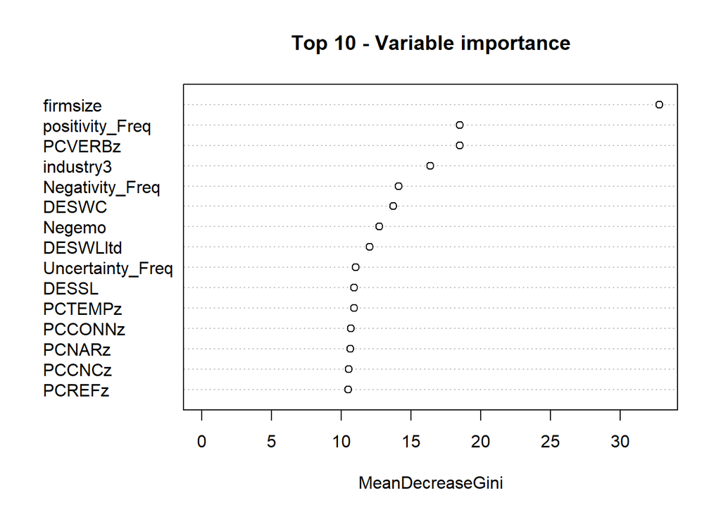

```r
varImpPlot(model3, sort = T, n.var = 15, main = "Top 10 - Variable importance")
```

```r
importance(model3)
```

```
##                          MeanDecreaseGini
## DESPC                            9.781207
## DESSC                            8.697589
## DESWC                           13.734339
## DESPL                            9.194596
## DESPLd                           9.648905
## DESSL                           10.929674
## DESSLd                           8.878345
## DESWLsy                          8.399737
## DESWLsyd                         8.290037
## DESWLlt                          7.830154
## DESWLltd                        12.035327
## Year                             6.783371
## PCNARz                          10.639782
## PCSYNz                           9.905701
## PCCNCz                          10.535818
## PCREFz                          10.477807
## PCDCz                            7.516517
## PCVERBz                         18.499009
## PCCONNz                         10.670081
## PCTEMPz                         10.904742
## Readabilityfleschkincaid         7.537539
## Readabilityfog                   8.459044
## industry3                       16.380596
## firmsize                        32.810139
## RDFRE                            7.895181
## RDFKGL                           9.432069
## Posemo                           8.683421
## Negemo                          12.743893
## Negativity_Freq                 14.092445
## positivity_Freq                 18.499784
## ForwardLooking_Freq              7.807108
## Uncertainty_Freq                11.048395
```

### 1. Classification problem (“poor” and “not poor” performance)

A Company has poor CSR performance if its CSR performance below 25%. However, a company does not have poor CSR performance if its CSR performance above 25%.

```r
remove(list = ls())
CSRdata <- read.csv("CSRScore.csv")
df <- CSRdata
df <- df[complete.cases(df), ]


CSRdata <- df[complete.cases(CSRdata), ]
df <- CSRdata[, -1] #Dropping "CSR"
df$y <- ifelse(CSRdata$CSR < 33.09217, 1, 0) #groups outcome variable CSR into “poor” and “not poor” categories.
table(df$y)
```

```
##
##   0   1
## 571 196
```

```r
# 1 indicates poor CSR perfromance and 0 indicates not poor CSR performance.

#Now, I will handle imbalanced data problem by using SMOTE.
library(DMwR)
df$y <- as.factor(df$y)
df <- SMOTE(y ~., df, perc.over =100, perc.under=200)
table(df$y)
```

```
##
##   0   1
## 383 392
```

```r
library(gplots)
library(PASWR)
library(ROCR)
library(rpart)
library(randomForest)
library(gbm)


df <- df[complete.cases(df), ]
df$d <- df$y
df$y <- as.integer(df$y)
df$y[df$y==1] <- 0
df$y[df$y==2] <- 1


n <- 20
B <- 1000
AUC1 <- c()
AUC2 <- c()
AUC3 <- c()
AUC4 <- c()

for (i in 1:n) {
  ind <- sample(nrow(df), nrow(df), replace = TRUE)
  train <- df[ind, ]
  test <- df[-ind, ]

  p = ncol(train)-2 #deleting survived and d columns. I need only 5 features.

  model1 <- rpart(y~., data=train[,-34], method = "class")
  model2 <- randomForest(d~., ntree = B, mtry = p, data = train[, -33]) #Bagged (-33 to drop y)
  model3 <- randomForest(d~., ntree = B, data = train[, -33]) # RF
  model4 <- gbm(y~., data=train[,-34], n.trees = B, distribution = "bernoulli") # Boosting

  phat1 <- predict(model1, test[,-34], type = "prob")
  phat2 <- predict(model2, test[,-33], type = "prob")
  phat3 <- predict(model3, test[,-33], type = "prob")
  phat4 <- predict(model4, n.trees = B, test[,-34], type = "response")

  #AUC1
  pred_rocr1 <- prediction(phat1[,2], test$y)
  auc_ROCR1 <- performance(pred_rocr1, measure = "auc")
  AUC1[i] <- auc_ROCR1@y.values[[1]]

  #AUC2
  pred_rocr2 <- prediction(phat2[,2], test$d)
  auc_ROCR2 <- performance(pred_rocr2, measure = "auc")
  AUC2[i] <- auc_ROCR2@y.values[[1]]

  #AUC3
  pred_rocr3 <- prediction(phat3[,2], test$d)
  auc_ROCR3 <- performance(pred_rocr3, measure = "auc")
  AUC3[i] <- auc_ROCR3@y.values[[1]]

  #AUC4
  pred_rocr4 <- prediction(phat4, test$y)
  auc_ROCR4 <- performance(pred_rocr4, measure = "auc")
  AUC4[i] <- auc_ROCR4@y.values[[1]]
}

mean(AUC1)
```

```
## [1] 0.7130463
```

```r
mean(AUC2)
```

```
## [1] 0.8776988
```

```r
mean(AUC3)
```

```
## [1] 0.8965402
```

```r
mean(AUC4)
```

```
## [1] 0.8288653
```

```r
sqrt(var(AUC1) * n / (n - 1))
```

```
## [1] 0.02842592
```

```r
sqrt(var(AUC2) * n / (n - 1))
```

```
## [1] 0.02346358
```

```r
sqrt(var(AUC3) * n / (n - 1))
```

```
## [1] 0.01655816
```

```r
sqrt(var(AUC4) * n / (n - 1))
```

```
## [1] 0.0198095
```

### 3. **Parametric models**: LPM, Logistic, LPM/Logistic models with Ridge and LASSO.

## 3. 1. LPM and Logistic

```r
remove(list = ls())
CSRdata <- read.csv("CSRScore.csv")
df <- CSRdata
df <- df[complete.cases(df), ]


CSRdata <- df[complete.cases(CSRdata), ]
df <- CSRdata[, -1] #Dropping "CSR"
df$y <- ifelse(CSRdata$CSR < 33.09217, 1, 0) #groups outcome variable CSR into “poor” and “not poor” categories.
table(df$y)
```

```
##
##   0   1
## 571 196
```

```r
#Now, I will handle imbalanced data problem by using SMOTE.
library(DMwR)
df$y <- as.factor(df$y)
df <- SMOTE(y ~., df, perc.over =100, perc.under=200)
table(df$y)
```

```
##
##   0   1
## 377 392
```

```r
library(PASWR)
library(ROCR)
library(rpart)

df$y <- as.integer(df$y)
df$y[df$y==1] <- 0
df$y[df$y==2] <- 1

n <- 500
AUC1 <- c()
AUC2 <- c()

for (i in 1:n) {
ind <- sample(nrow(df), nrow(df), replace = TRUE)
train <- df[ind, ]
test <- df[-ind, ]

model1 <- lm(y~., data=train)
model2 <- glm(y~.,data = train, family = binomial)


phat1 <- predict(model1, test, type = "response")
phat2 <- predict(model2, test, type = "response")

#AUC1
pred_rocr1 <- prediction(phat1, test$y)
auc_ROCR1 <- performance(pred_rocr1, measure = "auc")
AUC1[i] <- auc_ROCR1@y.values[[1]]

#AUC2
pred_rocr2 <- prediction(phat2, test$y)
auc_ROCR2 <- performance(pred_rocr2, measure = "auc")
AUC2[i] <- auc_ROCR2@y.values[[1]]
}
mean(AUC1)
```

```
## [1] 0.7146206
```

```r
mean(AUC2)
```

```
## [1] 0.714176
```

```r
sqrt(var(AUC1) * n / (n - 1))
```

```
## [1] 0.02526924
```

```r
sqrt(var(AUC2) * n / (n - 1))
```

```
## [1] 0.0254927
```

### 3 .2. Parametric models: LPM and Logistic models with Ridge and LASSO.

## 3. 2. 1. First, let us find the optimal value of lambda.

```r
remove(list = ls())
CSRdata <- read.csv("CSRScore.csv")
df <- CSRdata
df <- df[complete.cases(df), ]


CSRdata <- df[complete.cases(CSRdata), ]
df <- CSRdata[, -1] #Dropping "CSR"
df$y <- ifelse(CSRdata$CSR < 33.09217, 1, 0) #groups outcome variable CSR into “poor” and “not poor” categories.
table(df$y)
```

```
##
##   0   1
## 571 196
```

```r
#Now, I will handle imbalanced data problem by using SMOTE.
library(DMwR)
df$y <- as.factor(df$y)
df <- SMOTE(y ~., df, perc.over =100, perc.under=200)
table(df$y)
```

```
##
##   0   1
## 372 392
```

```r
library(PASWR)
library(ROCR)
library(rpart)
library(glmnet)

df <- df[complete.cases(df), ]
df$y <- as.integer(df$y)
#df$y[df$y==1] <- 0
#df$y[df$y==2] <- 1


grid = 10^seq(10, -2, length = 100)
AUC3 <- c() #LPM/Ridge
MAUC3<- c() #LPM/Ridge

AUC4 <- c() #LPM/LASSO
MAUC4 <- c() #LPM/LASSO

AUC5 <- c() #Logistic/Ridge
MAUC5 <- c() #Logistic/Ridge

AUC6 <- c() #Logistic/LASSO
MAUC6 <- c() #Logistic/LASSO

for(i in 1:length(grid)){
for(j in 1:100){
set.seed(j)
ind <- sample(nrow(df), nrow(df), replace = TRUE)
#ind <- unique(ind)

train <- df[ind, ]
xtrain <- model.matrix(y~., train)[,-33]
ytrain <- df[ind, 33]

test <- df[-ind, ]
xtest <- model.matrix(y~., test)[,-33]
ytest <- df[-ind, 33]


model3 <- glmnet(xtrain, ytrain, alpha = 0, lambda = grid[i], thresh = 1e-12,)#LPM/Ridge
model4 <- glmnet(xtrain, ytrain, alpha = 1, lambda = grid[i], thresh = 1e-12,)#LPM/LASSO
model5 <- glmnet(xtrain, ytrain, alpha = 0, lambda = grid[i], thresh = 1e-12, family = "binomial") #Logistic/Ridge
model6 <- glmnet(xtrain, ytrain, alpha = 1, lambda = grid[i], thresh = 1e-12, family = "binomial") #Logistic/LASSO


phat3 <- predict(model3, s = grid[i], newx = xtest, type = "response")
phat4 <- predict(model4, s = grid[i], newx = xtest, type = "response")
phat5 <- predict(model5, s = grid[i], newx = xtest, type = "response")
phat6 <- predict(model6, s = grid[i], newx = xtest, type = "response")


#AUC3
pred3 <- prediction(phat3, ytest)
auc3 <- performance(pred3, measure = "auc")
AUC3[j] <- auc3@y.values[[1]]

#AUC4
pred4 <- prediction(phat4, ytest)
auc4 <- performance(pred4, measure = "auc")
AUC4[j] <- auc4@y.values[[1]]

#AUC5
pred5 <- prediction(phat5, ytest)
auc5 <- performance(pred5, measure = "auc")
AUC5[j] <- auc5@y.values[[1]]

#AUC6
pred6 <- prediction(phat6, ytest)
auc6 <- performance(pred6, measure = "auc")
AUC6[j] <- auc6@y.values[[1]]
}

MAUC3[i] <- mean(AUC3)
MAUC4[i] <- mean(AUC4)
MAUC5[i] <- mean(AUC5)
MAUC6[i] <- mean(AUC6)
}

max(MAUC3)
```

```
## [1] 0.7415384
```

```r
max(MAUC4)
```

```
## [1] 0.7411836
```

```r
max(MAUC5)
```

```
## [1] 0.7410223
```

```r
max(MAUC6)
```

```
## [1] 0.7407399
```

```r
grid[which.max(MAUC3)]
```

```
## [1] 0.3764936
```

```r
grid[which.max(MAUC4)]
```

```
## [1] 0.01321941
```

```r
grid[which.max(MAUC5)]
```

```
## [1] 0.1232847
```

```r
grid[which.max(MAUC6)]
```

```
## [1] 0.01321941
```

```r
remove(list = ls())
CSRdata <- read.csv("CSRScore.csv")
df <- CSRdata
df <- df[complete.cases(df), ]


CSRdata <- df[complete.cases(CSRdata), ]
df <- CSRdata[, -1] #Dropping "CSR"
df$y <- ifelse(CSRdata$CSR < 33.09217, 1, 0) #groups outcome variable CSR into “poor” and “not poor” categories.
table(df$y)
```

```
##
##   0   1
## 571 196
```

```r
#Now, I will handle imbalanced data problem by using SMOTE.
library(DMwR)
df$y <- as.factor(df$y)
df <- SMOTE(y ~., df, perc.over =100, perc.under=200)
table(df$y)
```

```
##
##   0   1
## 376 392
```

```r
library(PASWR)
library(ROCR)
library(rpart)
library(glmnet)

df <- df[complete.cases(df), ]
df$y <- as.integer(df$y)

AUC3 <- c() #LPM/Ridge
MAUC3<- c() #LPM/Ridge

AUC4 <- c() #LPM/LASSO
MAUC4 <- c() #LPM/LASSO

AUC5 <- c() #Logistic/Ridge
MAUC5 <- c() #Logistic/Ridge

AUC6 <- c() #Logistic/LASSO
MAUC6 <- c() #Logistic/LASSO


for(i in 1:500){
ind <- sample(nrow(df), nrow(df), replace = TRUE)
ind <- unique(ind)
train <- df[ind, ]
xtrain <- model.matrix(y~., train)[,-33]
ytrain <- df[ind, 33]
test <- df[-ind, ]
xtest <- model.matrix(y~., test)[,-33]
ytest <- df[-ind, 33]


model3 <- glmnet(xtrain, ytrain, alpha = 0, lambda = 0.3764936, thresh = 1e-12,)#LPM/Ridge
model4 <- glmnet(xtrain, ytrain, alpha = 1, lambda = 0.01321941, thresh = 1e-12,)#LPM/LASSO
model5 <- glmnet(xtrain, ytrain, alpha = 0, lambda = 0.1629751, thresh = 1e-12, family = "binomial") #Logistic/Ridge
model6 <- glmnet(xtrain, ytrain, alpha = 1, lambda = 0.01321941, thresh = 1e-12, family = "binomial") #Logistic/LASSO


phat3 <- predict(model3, s = 0.3764936, newx = xtest, type = "response")
phat4 <- predict(model4, s = 0.01321941, newx = xtest, type = "response")
phat5 <- predict(model5, s = 0.1629751, newx = xtest, type = "response")
phat6 <- predict(model6, s = 0.01321941, newx = xtest, type = "response")


#AUC3
pred3 <- prediction(phat3, ytest)
auc3 <- performance(pred3, measure = "auc")
AUC3[i] <- auc3@y.values[[1]]

#AUC4
pred4 <- prediction(phat4, ytest)
auc4 <- performance(pred4, measure = "auc")
AUC4[i] <- auc4@y.values[[1]]

#AUC5
pred5 <- prediction(phat5, ytest)
auc5 <- performance(pred5, measure = "auc")
AUC5[i] <- auc5@y.values[[1]]

#AUC6
pred6 <- prediction(phat6, ytest)
auc6 <- performance(pred6, measure = "auc")
AUC6[i] <- auc6@y.values[[1]]
}



mean(AUC3)
```

```
## [1] 0.7219372
```

```r
mean(AUC4)
```

```
## [1] 0.7190738
```

```r
mean(AUC5)
```

```
## [1] 0.7215305
```

```r
mean(AUC6)
```

```
## [1] 0.7186828
```

```r
sqrt(var(AUC3)*500/499)
```

```
## [1] 0.02476106
```

```r
sqrt(var(AUC4)*500/499)
```

```
## [1] 0.02477897
```

```r
sqrt(var(AUC5)*500/499)
```

```
## [1] 0.02480175
```

```r
sqrt(var(AUC6)*500/499)
```

```
## [1] 0.02489835
```